# NHL Shot Effectiveness Model

Sasank Vishnubhatla

February 8th, 2019

Last Update: 2019-02-24 16:02:57

# Libraries

Before we start, let’s load a few libraries.

```r
rm(list = ls())

options(warn = -1)

library(knitr)
library(ggplot2)
library(caret)
library(doParallel)

registerDoParallel(cores = (detectCores() - 1))
```

With our libraries loaded we can start loading our data.

# Data Loading

Let’s read in our data.

```r
data.2015 = read.csv("data/2015.csv")
data.2016 = read.csv("data/2016.csv")
data.2017 = read.csv("data/2017.csv")
data.2018 = read.csv("data/2018.csv")
```

Now, we will only deal with regular season events. So let’s remove the playoffs from our datasets.

```r
get.regular.season = function(data) {
    subset(data, isPlayoffGame == 0)
}

season.2015 = get.regular.season(data.2015)
season.2016 = get.regular.season(data.2016)
season.2017 = get.regular.season(data.2017)
season.2018 = get.regular.season(data.2018)
```

Here is a table of all the columns we shall keep and what we shall rename them to.

| Old Column Name | New Column Name |
| --- | --- |
| `xCordAdjusted` | `x` |
| `yCordAdjusted` | `y` |
| `shotAngleAdjusted` | `angle` |
| `shotDistance` | `dist` |
| `teamCode` | `team` |
| `shotType` | `type` |

```r
get.helpful.data = function(data) {
    data.frame(x = data$xCordAdjusted,
               y = data$yCordAdjusted,
               angle = data$shotAngleAdjusted,
               dist = data$shotDistance,
               type = data$shotType,
               typeNum = as.numeric(data$shotType),
               goal = data$goal,
               team = data$teamCode)
}

# type:
# 1 -> empty
# 2 -> BACK
# 3 -> DEFL
# 4 -> SLAP
# 5 -> SNAP
# 6 -> TIP
# 7 -> WRAP
# 8 -> WRIST

analysis.2015 = get.helpful.data(season.2015)
analysis.2016 = get.helpful.data(season.2016)
analysis.2017 = get.helpful.data(season.2017)
analysis.2018 = get.helpful.data(season.2018)
```

Now, we can remove incomplete cases and create our machine learning model’s giant data set.

```r
analysis.2015 = analysis.2015[complete.cases(analysis.2015),]
analysis.2016 = analysis.2016[complete.cases(analysis.2016),]
analysis.2017 = analysis.2017[complete.cases(analysis.2017),]
analysis.all = rbind(analysis.2017, rbind(analysis.2016, analysis.2015))
analysis.all = analysis.all[complete.cases(analysis.all),]
analysis.2018 = analysis.2018[complete.cases(analysis.2018),]
```

Here’s what `analysis.2018` looks like:

```r
analysis.2018
```

|  | x | y | angle | dist | type | typeNum | goal | team |
| --- | --- | --- | --- | --- | --- | --- | --- | --- |
| 1 | 78 | -19 | 59.9314172 | 21.954498 | BACK | 2 | 0 | MTL |
| 2 | 37 | 10 | 10.8855271 | 52.952809 | SNAP | 5 | 0 | TOR |
| 3 | 47 | -23 | 28.7059525 | 47.885280 | WRIST | 8 | 0 | MTL |
| 4 | 73 | 22 | 53.9726266 | 27.202941 | SNAP | 5 | 0 | MTL |
| 5 | 53 | 14 | 21.2505055 | 38.626416 | SNAP | 5 | 0 | MTL |
| 6 | 81 | -4 | 26.5650512 | 8.944272 | TIP | 6 | 0 | MTL |
| 7 | 77 | -2 | 9.4623222 | 12.165525 | SNAP | 5 | 0 | MTL |
| 8 | 80 | 1 | 6.3401917 | 9.055385 | BACK | 2 | 0 | MTL |
| 9 | 67 | -4 | 10.3048465 | 22.360680 | WRIST | 8 | 0 | TOR |
| 10 | 75 | 8 | 29.7448813 | 16.124515 | WRIST | 8 | 0 | TOR |

[output cut: 990 more lines]

```r
get.team.data = function(data, code) {
    subset(data, team == code)
}
```

# Calculating Statistics

We can calculate a few statistics, like goal (effective) percentage for a certain shot. Let’s write a function to do that right now.

```r
calculate.goal.percentage = function(data) {
    goals = sum(data$goal == 1)
    total = nrow(data)
    goals / total
}
```

So, for example, Penguins’s goal percentage against slap shots would be calculated as follows:

```r
penguins.2018 = get.team.data(analysis.2018, "PIT")
penguins.2018.slap = subset(penguins.2018, type == 4)
penguins.2018.slap.eff = calculate.goal.percentage(penguins.2018.slap)
```

Their goal percentage is NaN.

# Creating the Models

Using the `caret` package, we can build machine learning models to help us determine which shot type is best.

Let’s get started with training our control.

```r
control = trainControl(method = "repeatedcv", number = 5, repeats = 3)
```

Now we will train a few different types of models. Here is a list of the models we will train:

- Neural Network
- K Nearest Neighbors

```r
model.nnet = train(goal ~ . -goal -team -type,
                   data = analysis.all,
                   method = "nnet",
                   trControl = control)
model.knn = train(goal ~ . -goal -team -type,
                  data = analysis.all,
                  method = "knn",
                  trControl = control)
```

Now our models have been made.

# Testing the Models

Let’s test our models on the 2018 data. Here’s what the testing data looks like:

```r
analysis.2018
```

|  | x | y | angle | dist | type | typeNum | goal | team |
| --- | --- | --- | --- | --- | --- | --- | --- | --- |
| 1 | 78 | -19 | 59.9314172 | 21.954498 | BACK | 2 | 0 | MTL |
| 2 | 37 | 10 | 10.8855271 | 52.952809 | SNAP | 5 | 0 | TOR |
| 3 | 47 | -23 | 28.7059525 | 47.885280 | WRIST | 8 | 0 | MTL |
| 4 | 73 | 22 | 53.9726266 | 27.202941 | SNAP | 5 | 0 | MTL |
| 5 | 53 | 14 | 21.2505055 | 38.626416 | SNAP | 5 | 0 | MTL |
| 6 | 81 | -4 | 26.5650512 | 8.944272 | TIP | 6 | 0 | MTL |
| 7 | 77 | -2 | 9.4623222 | 12.165525 | SNAP | 5 | 0 | MTL |
| 8 | 80 | 1 | 6.3401917 | 9.055385 | BACK | 2 | 0 | MTL |
| 9 | 67 | -4 | 10.3048465 | 22.360680 | WRIST | 8 | 0 | TOR |
| 10 | 75 | 8 | 29.7448813 | 16.124515 | WRIST | 8 | 0 | TOR |

[output cut: 990 more lines]

Now, let’s get our predictions:

```r
nnet.prediction = predict(model.nnet, newdata = analysis.2018)
knn.prediction = predict(model.knn, newdata = analysis.2018)

nnet.prediction.data = data.frame(analysis.2018)
nnet.prediction.data$predict = nnet.prediction

knn.prediction.data = data.frame(analysis.2018)
knn.prediction.data$predict = knn.prediction
```

So, our Neural Network data looks like:

```r
nnet.prediction.data
```

|  | x | y | angle | dist | type | typeNum | goal | team | predict |
| --- | --- | --- | --- | --- | --- | --- | --- | --- | --- |
| 1 | 78 | -19 | 59.9314172 | 21.954498 | BACK | 2 | 0 | MTL | 0.04592692 |
| 2 | 37 | 10 | 10.8855271 | 52.952809 | SNAP | 5 | 0 | TOR | 0.02656534 |
| 3 | 47 | -23 | 28.7059525 | 47.885280 | WRIST | 8 | 0 | MTL | 0.02756082 |
| 4 | 73 | 22 | 53.9726266 | 27.202941 | SNAP | 5 | 0 | MTL | 0.04222904 |
| 5 | 53 | 14 | 21.2505055 | 38.626416 | SNAP | 5 | 0 | MTL | 0.04019080 |
| 6 | 81 | -4 | 26.5650512 | 8.944272 | TIP | 6 | 0 | MTL | 0.17255039 |
| 7 | 77 | -2 | 9.4623222 | 12.165525 | SNAP | 5 | 0 | MTL | 0.13528637 |
| 8 | 80 | 1 | 6.3401917 | 9.055385 | BACK | 2 | 0 | MTL | 0.18783886 |
| 9 | 67 | -4 | 10.3048465 | 22.360680 | WRIST | 8 | 0 | TOR | 0.12222547 |
| 10 | 75 | 8 | 29.7448813 | 16.124515 | WRIST | 8 | 0 | TOR | 0.11742414 |

[output cut: 990 more lines]

Our K-Nearest Neighbors data looks like:

```r
knn.prediction.data
```

|  | x | y | angle | dist | type | typeNum | goal | team | predict |
| --- | --- | --- | --- | --- | --- | --- | --- | --- | --- |
| 1 | 78 | -19 | 59.9314172 | 21.954498 | BACK | 2 | 0 | MTL | 0.00000000 |
| 2 | 37 | 10 | 10.8855271 | 52.952809 | SNAP | 5 | 0 | TOR | 0.00000000 |
| 3 | 47 | -23 | 28.7059525 | 47.885280 | WRIST | 8 | 0 | MTL | 0.00000000 |
| 4 | 73 | 22 | 53.9726266 | 27.202941 | SNAP | 5 | 0 | MTL | 0.00000000 |
| 5 | 53 | 14 | 21.2505055 | 38.626416 | SNAP | 5 | 0 | MTL | 0.00000000 |
| 6 | 81 | -4 | 26.5650512 | 8.944272 | TIP | 6 | 0 | MTL | 0.22222222 |
| 7 | 77 | -2 | 9.4623222 | 12.165525 | SNAP | 5 | 0 | MTL | 0.06250000 |
| 8 | 80 | 1 | 6.3401917 | 9.055385 | BACK | 2 | 0 | MTL | 0.13235294 |
| 9 | 67 | -4 | 10.3048465 | 22.360680 | WRIST | 8 | 0 | TOR | 0.12903226 |
| 10 | 75 | 8 | 29.7448813 | 16.124515 | WRIST | 8 | 0 | TOR | 0.12359551 |

[output cut: 990 more lines]

# Visualizing the Predictions

Let us visualize how distance and the goal prediction are related.

```r
make.knn.dist.plot = function(data, primary, secondary, team) {
    name = paste(team, "Predicted Goal Probability versus Distance (KNN)", sep = " ")
    plot = ggplot(data) +
        geom_smooth(aes(x = dist, y = predict), method = "auto",
                 fill = secondary, color = primary) +
        labs(title = name,
             x = "Distance from Net",
             y = "Probability of Scoring") +
        theme_minimal()
    plot
}
```

Here’s the same function, but for the neural network data.

```r
make.nnet.dist.plot = function(data, primary, secondary, team) {
    name = paste(team, "Predicted Goal Probability versus Distance (NNet)", sep = " ")
    plot = ggplot(data) +
        geom_smooth(aes(x = dist, y = predict), method = "auto",
                 fill = secondary, color = primary) +
        labs(title = name,
             x = "Distance from Net",
             y = "Probability of Scoring") +
        theme_minimal()
    plot
}
```

Now let’s visualize the frequency of a shot.

```r
make.type.freq.plot = function(data, primary, secondary, team) {
  name = paste(team, "Frequency per Shot Type", seq = " ")
  plot = ggplot(data) +
    geom_bar(aes(x = type), stat = "count",
                   fill = secondary, color = primary) +
    labs(title = name, x = "Shot Type", y = "Count") +
    theme_minimal()
  plot
}
```

The next graph is comparing type and goal prediction.

```r
make.knn.type.plot = function(data, primary, secondary, team) {
  name = paste(team, "Predicted Goal versus Shot Type (KNN)", seq = " ")
  plot = ggplot(data) +
    geom_jitter(aes(x = type, y = predict), fill = primary, color = secondary) +
    labs(title = name, x = "Shot Type", y = "Probability of Scoring") +
    theme_minimal()
  plot
}
```

Here is the neural net flavor of the last function.

```r
make.nnet.type.plot = function(data, primary, secondary, team) {
  name = paste(team, "Predicted Goal versus Shot Type (NNet)", seq = " ")
  plot = ggplot(data) +
    geom_jitter(aes(x = type, y = predict), fill = primary, color = secondary) +
    labs(title = name, x = "Shot Type", y = "Probability of Scoring") +
    theme_minimal()
  plot
}
```

# Examples

## Pittsburgh Penguins

Let’s get our data from the Neural Network and K-Nearest Neighbors algorithms.

```r
pit.nnet = get.team.data(nnet.prediction.data, "PIT")
pit.knn = get.team.data(knn.prediction.data, "PIT")
```

Let’s just visualize our shots type data.

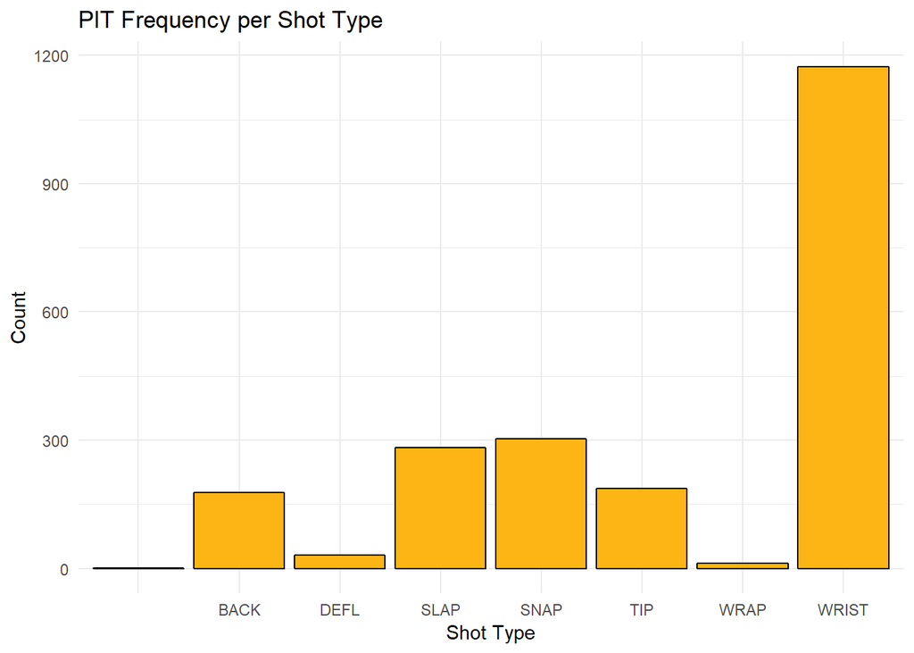

```r
pit.type.freq = make.type.freq.plot(pit.nnet, "#000000", "#FCB514", "PIT")

pit.type.freq
```

Here is how the Penguins did with shots versus goal probability from the KNN model.

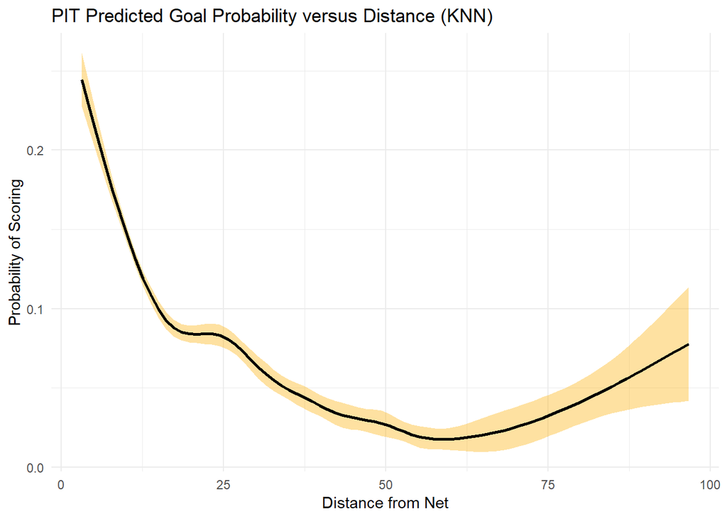

```r
pit.knn.dist = make.knn.dist.plot(pit.knn, "#000000", "#FCB514", "PIT")

pit.knn.dist
```

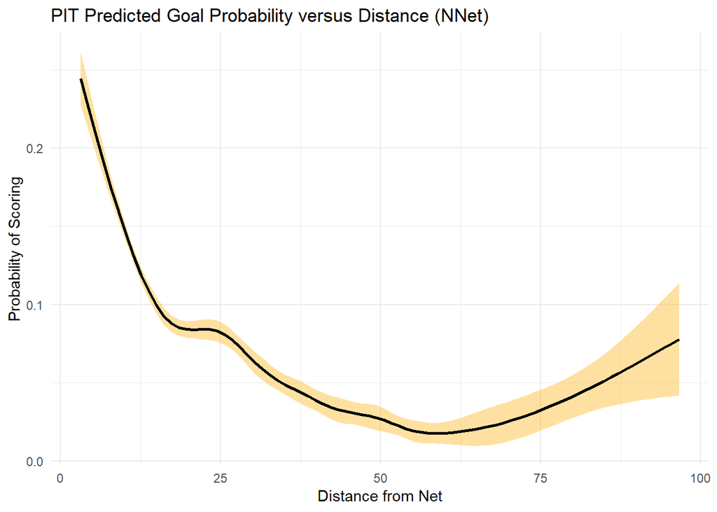

```r
pit.nnet.dist = make.nnet.dist.plot(pit.knn, "#000000", "#FCB514", "PIT")

pit.nnet.dist
```

Now let’s look at shot type versus goal probability.

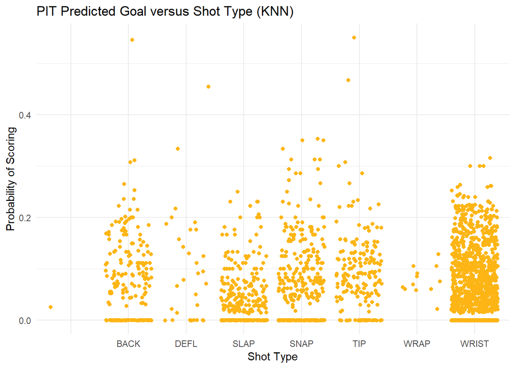

```r
pit.knn.type = make.knn.type.plot(pit.knn, "#000000", "#FCB514", "PIT")

pit.knn.type
```

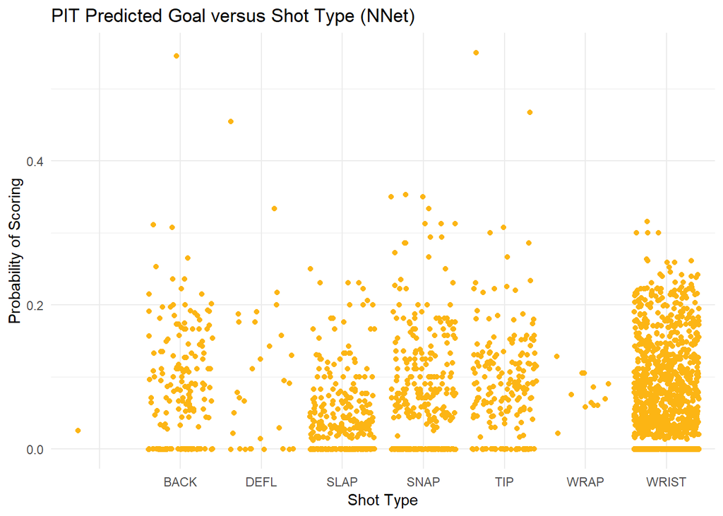

```r
pit.nnet.type = make.nnet.type.plot(pit.knn, "#000000", "#FCB514", "PIT")

pit.nnet.type
```

## Vegas Golden Knights

Let’s get our data from the Neural Network and K-Nearest Neighbors algorithms.

```r
vgk.nnet = get.team.data(nnet.prediction.data, "VGK")
vgk.knn = get.team.data(knn.prediction.data, "VGK")
```

Let’s just visualize our shots type data.

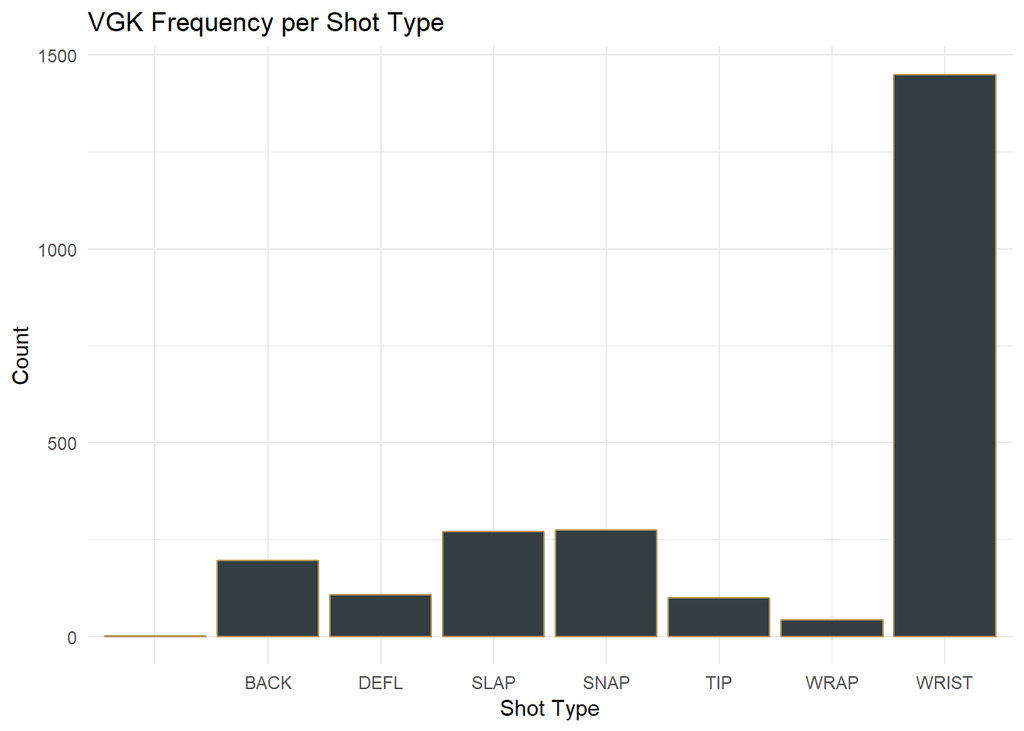

```r
vgk.type.freq = make.type.freq.plot(vgk.nnet, "#B4975A", "#333F42", "VGK")

vgk.type.freq
```

Here is how the Golden Knights did with shots versus goal probability from the KNN model.

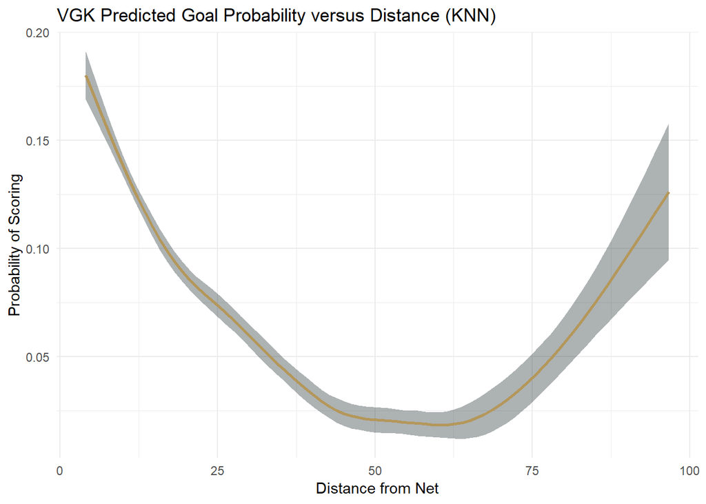

```r
vgk.knn.dist = make.knn.dist.plot(vgk.knn, "#B4975A", "#333F42", "VGK")

vgk.knn.dist
```

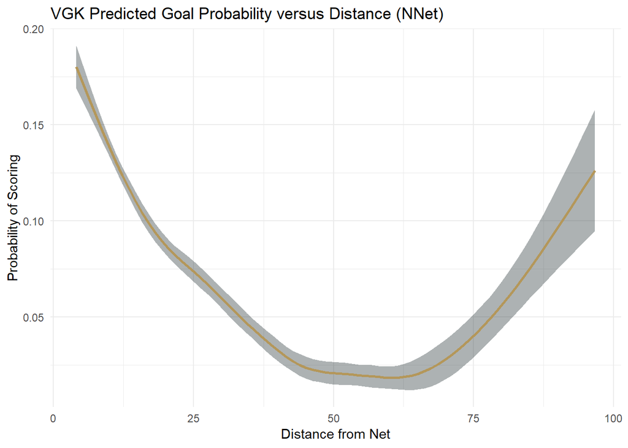

```r
vgk.nnet.dist = make.nnet.dist.plot(vgk.knn, "#B4975A", "#333F42", "VGK")

vgk.nnet.dist
```

Now let’s look at shot type versus goal probability.

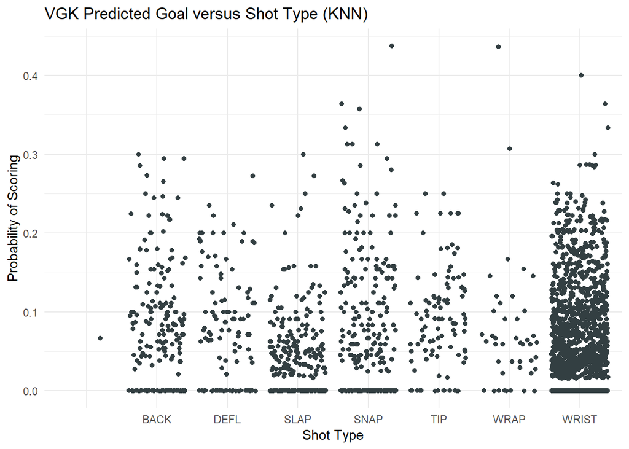

```r
vgk.knn.type = make.knn.type.plot(vgk.knn, "#B4975A", "#333F42", "VGK")

vgk.knn.type
```

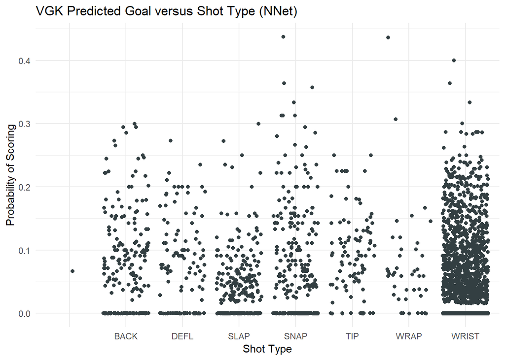

```r
vgk.nnet.type = make.nnet.type.plot(vgk.knn, "#B4975A", "#333F42", "VGK")

vgk.nnet.type
```

## Winnipeg Jets

Let’s get our data from the Neural Network and K-Nearest Neighbors algorithms.

```r
wpg.nnet = get.team.data(nnet.prediction.data, "WPG")
wpg.knn = get.team.data(knn.prediction.data, "WPG")
```

Let’s just visualize our shots type data.

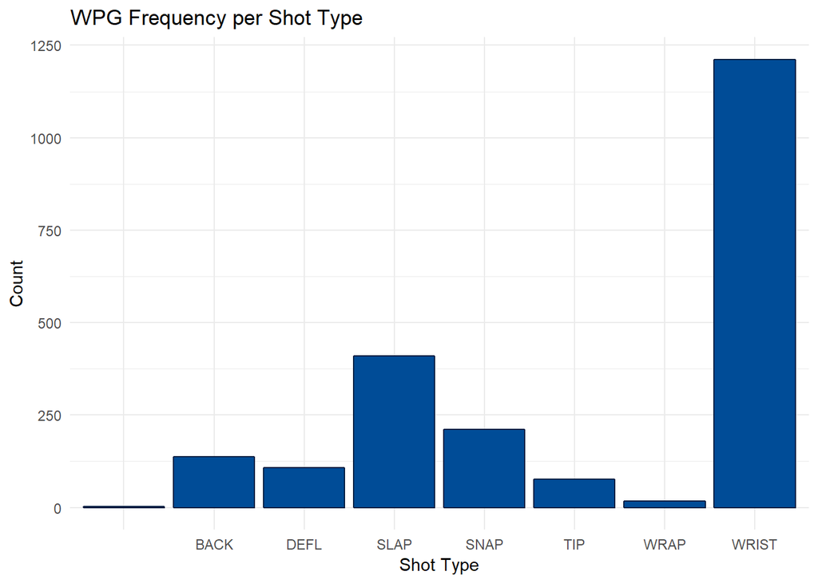

```r
wpg.type.freq = make.type.freq.plot(wpg.nnet, "#041E42", "#004C97", "WPG")

wpg.type.freq
```

Here is how the Jets did with shots versus goal probability from the KNN model.

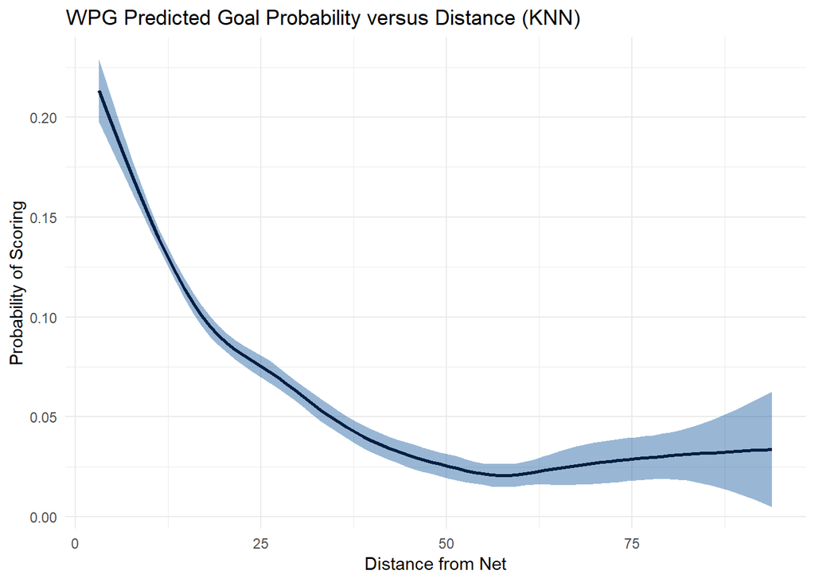

```r
wpg.knn.dist = make.knn.dist.plot(wpg.knn, "#041E42", "#004C97", "WPG")

wpg.knn.dist
```

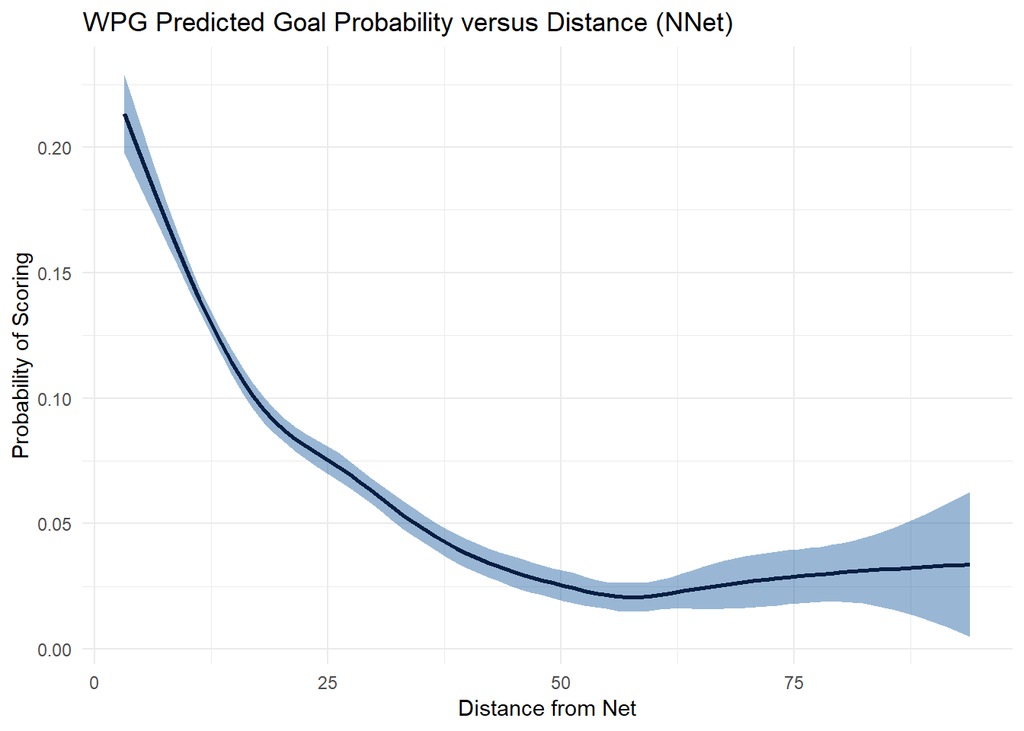

```r
wpg.nnet.dist = make.nnet.dist.plot(wpg.knn, "#041E42", "#004C97", "WPG")

wpg.nnet.dist
```

Now let’s look at shot type versus goal probability.

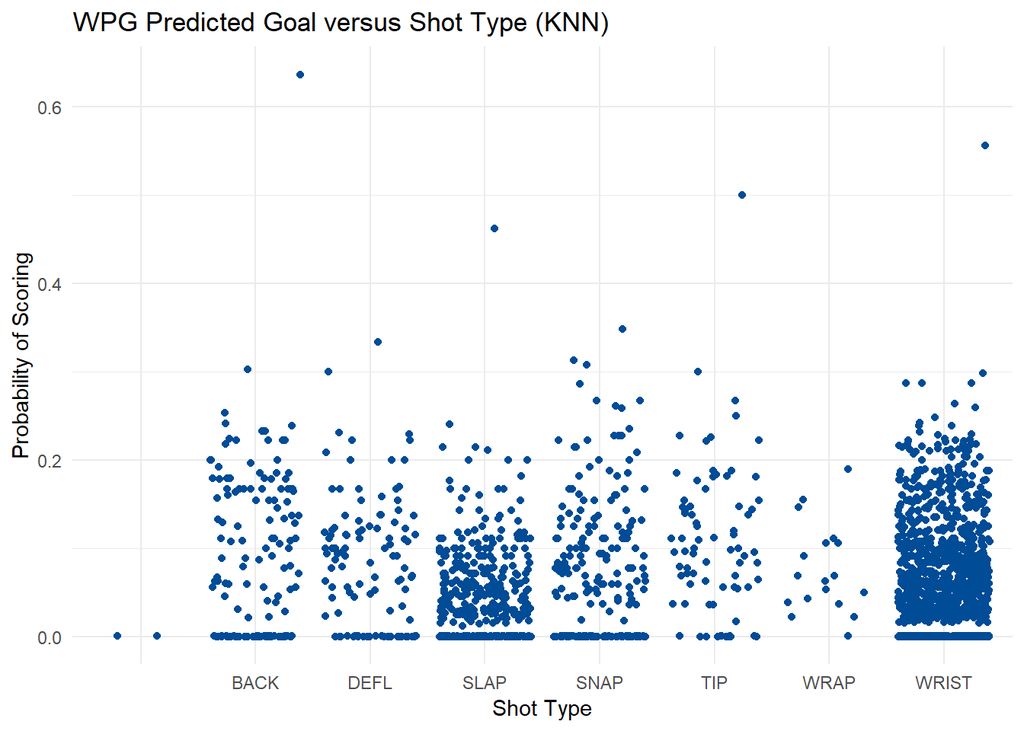

```r
wpg.knn.type = make.knn.type.plot(wpg.knn, "#041E42", "#004C97", "WPG")

wpg.knn.type
```

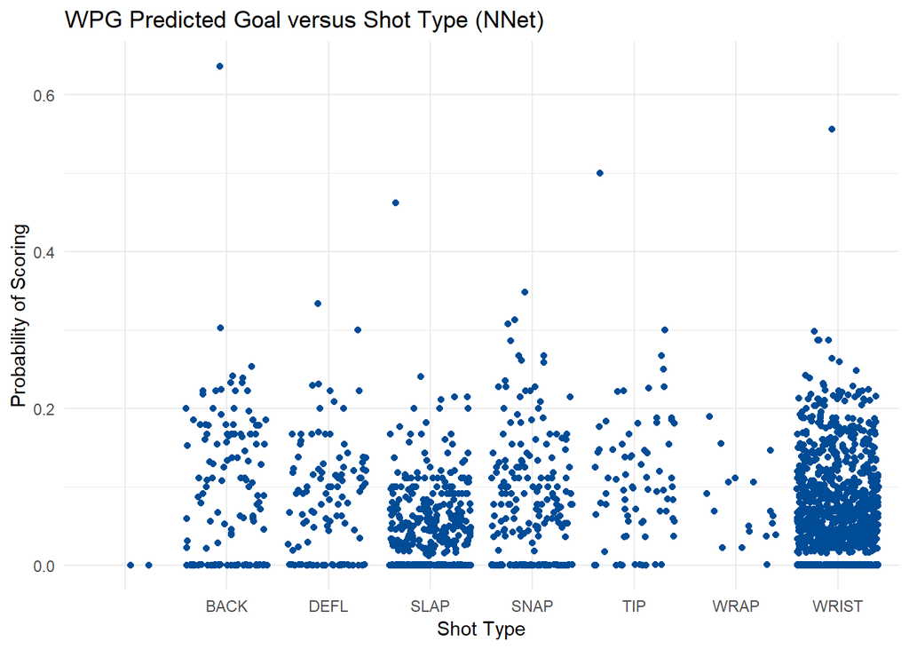

```r
wpg.nnet.type = make.nnet.type.plot(wpg.knn, "#041E42", "#004C97", "WPG")

wpg.nnet.type
```

## Tampa Bay Lightning

Let’s get our data from the Neural Network and K-Nearest Neighbors algorithms.

```r
tbl.nnet = get.team.data(nnet.prediction.data, "T.B")
tbl.knn = get.team.data(knn.prediction.data, "T.B")
```

Let’s just visualize our shots type data.

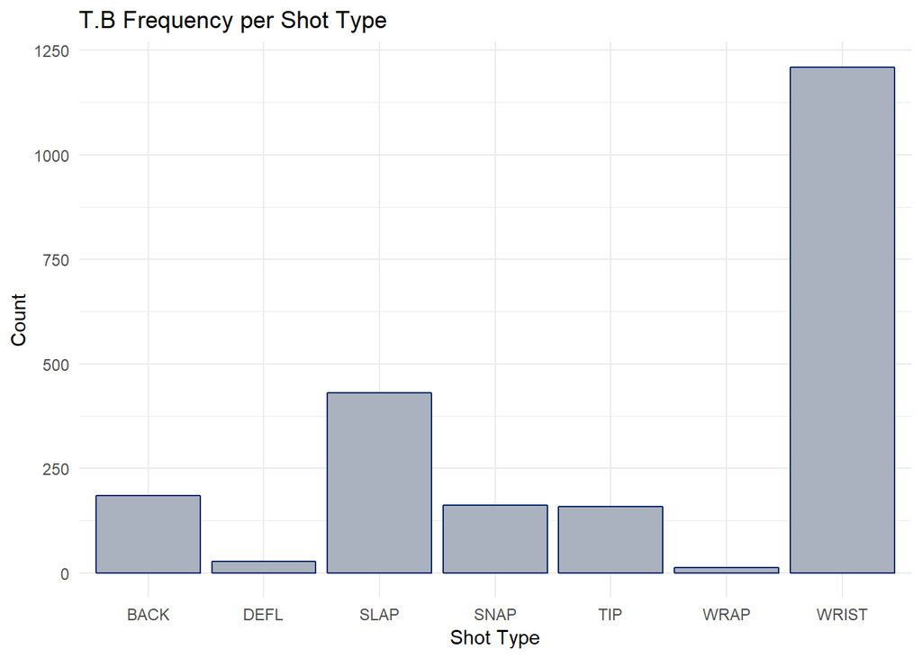

```r
tbl.type.freq = make.type.freq.plot(tbl.nnet, "#002868", "#AAB1BF", "T.B")

tbl.type.freq
```

Here is how the Lightning did with shots versus goal probability from the KNN model.

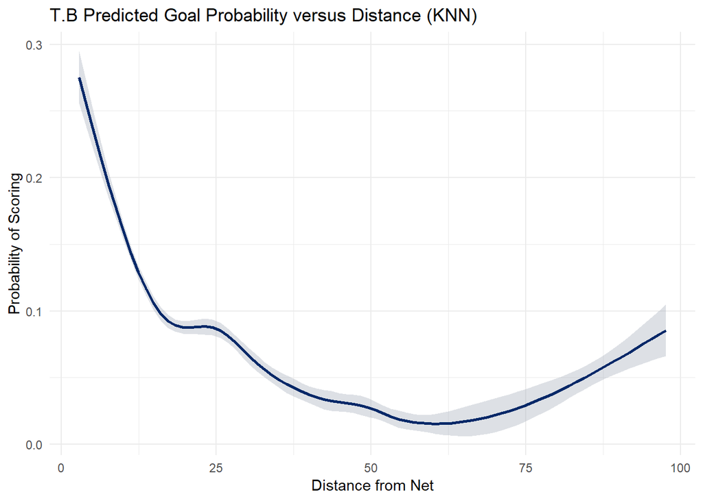

```r
tbl.knn.dist = make.knn.dist.plot(tbl.knn, "#002868", "#AAB1BF", "T.B")

tbl.knn.dist
```

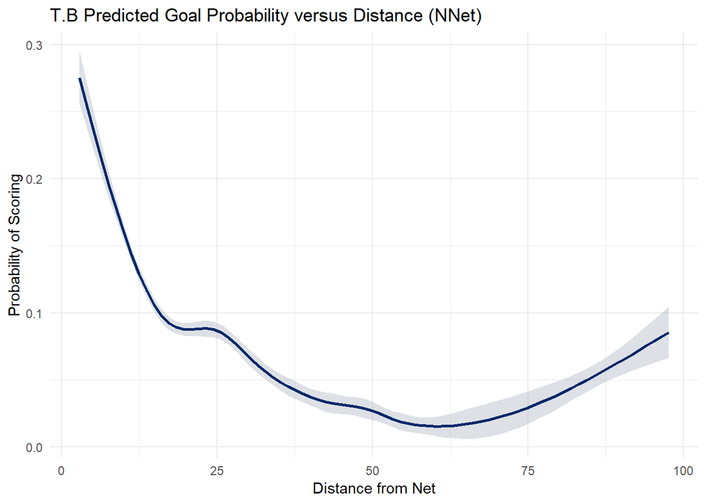

```r
tbl.nnet.dist = make.nnet.dist.plot(tbl.knn, "#002868", "#AAB1BF", "T.B")

tbl.nnet.dist
```

Now let’s look at shot type versus goal probability.

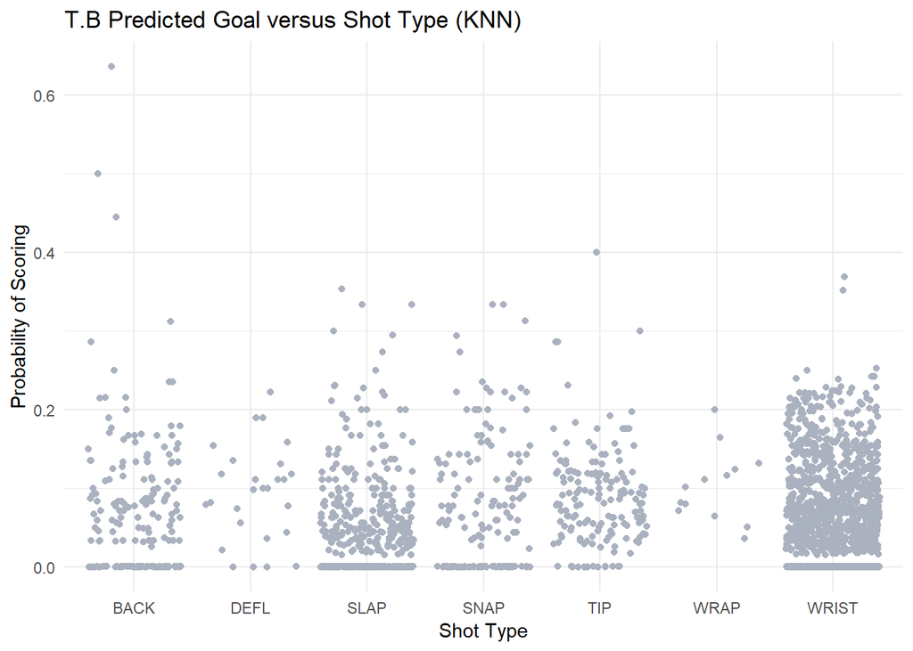

```r
tbl.knn.type = make.knn.type.plot(tbl.knn, "#002868", "#AAB1BF", "T.B")

tbl.knn.type
```

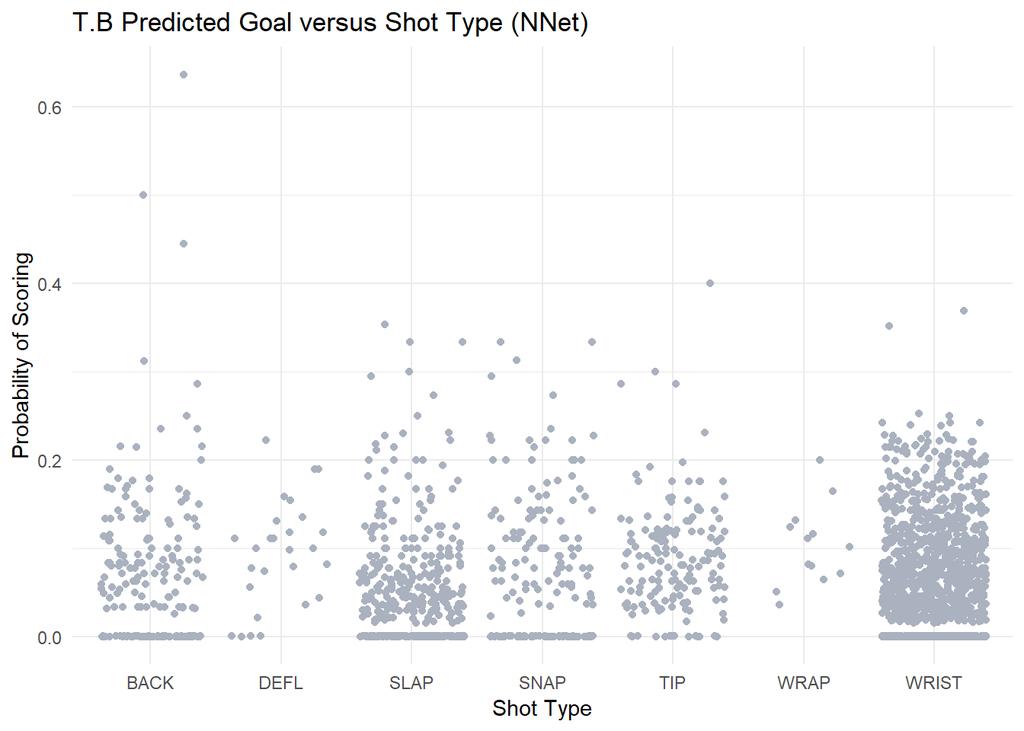

```r
tbl.nnet.type = make.nnet.type.plot(tbl.knn, "#002868", "#AAB1BF", "T.B")

tbl.nnet.type
```

## Toronto Maple Leafs

Let’s get our data from the Neural Network and K-Nearest Neighbors algorithms.

```r
tor.nnet = get.team.data(nnet.prediction.data, "TOR")
tor.knn = get.team.data(knn.prediction.data, "TOR")
```

Let’s just visualize our shots type data.

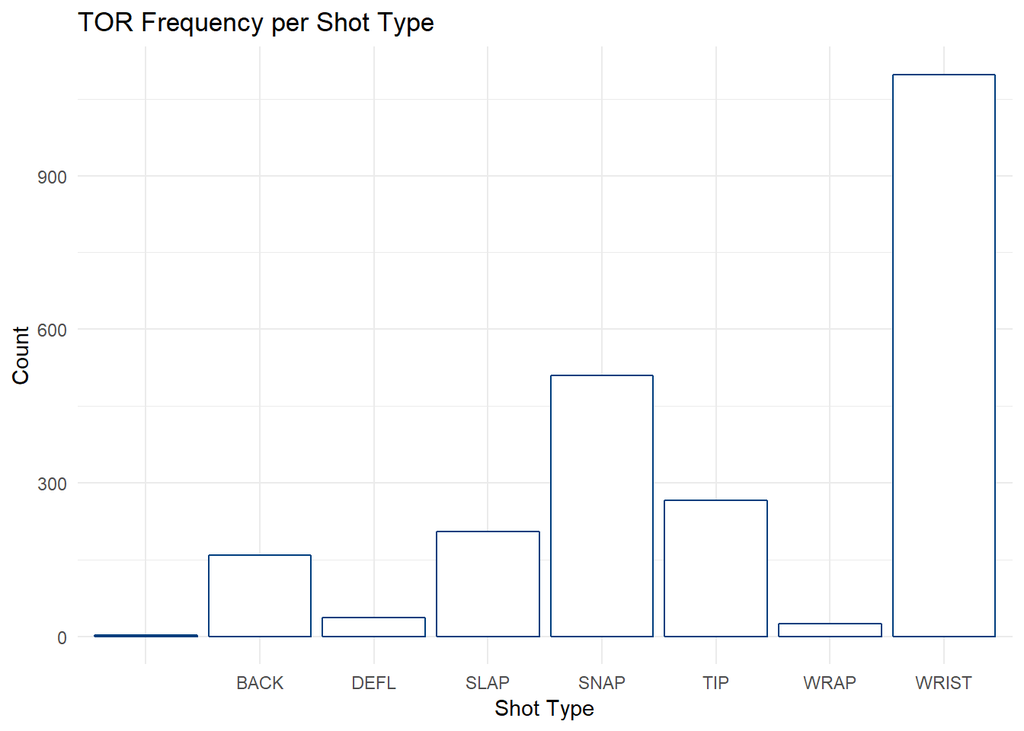

```r
tor.type.freq = make.type.freq.plot(tor.nnet, "#003E7E", "#FFFFFF", "TOR")

tor.type.freq
```

Here is how the Maple Leafs did with shots versus goal probability from the KNN model.

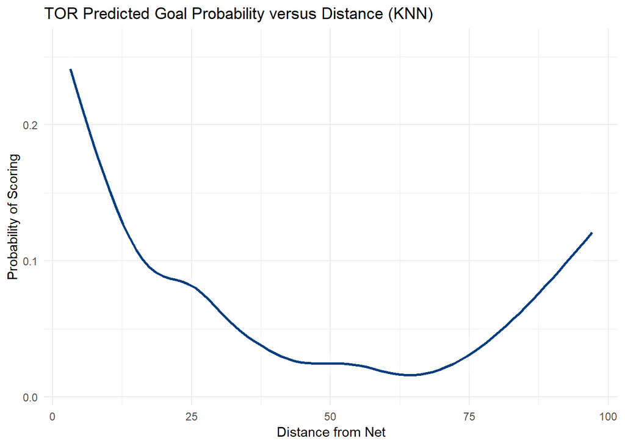

```r
tor.knn.dist = make.knn.dist.plot(tor.knn, "#003E7E", "#FFFFFF", "TOR")

tor.knn.dist
```

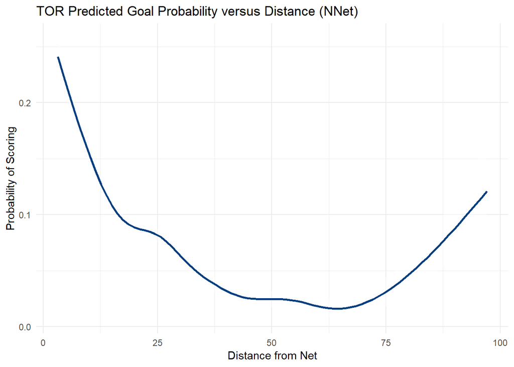

```r
tor.nnet.dist = make.nnet.dist.plot(tor.knn, "#003E7E", "#FFFFFF", "TOR")

tor.nnet.dist
```

Now let’s look at shot type versus goal probability.

[figure not shown]

```r
tor.knn.type = make.knn.type.plot(tor.knn, "#003E7E", "#FFFFFF", "TOR")

tor.knn.type
```

[figure not shown]

```r
tor.nnet.type = make.nnet.type.plot(tor.knn, "#003E7E", "#FFFFFF", "TOR")

tor.nnet.type
```

## Colorado Avalance

Let’s get our data from the Neural Network and K-Nearest Neighbors algorithms.

```r
col.nnet = get.team.data(nnet.prediction.data, "COL")
col.knn = get.team.data(knn.prediction.data, "COL")
```

Let’s just visualize our shots type data.

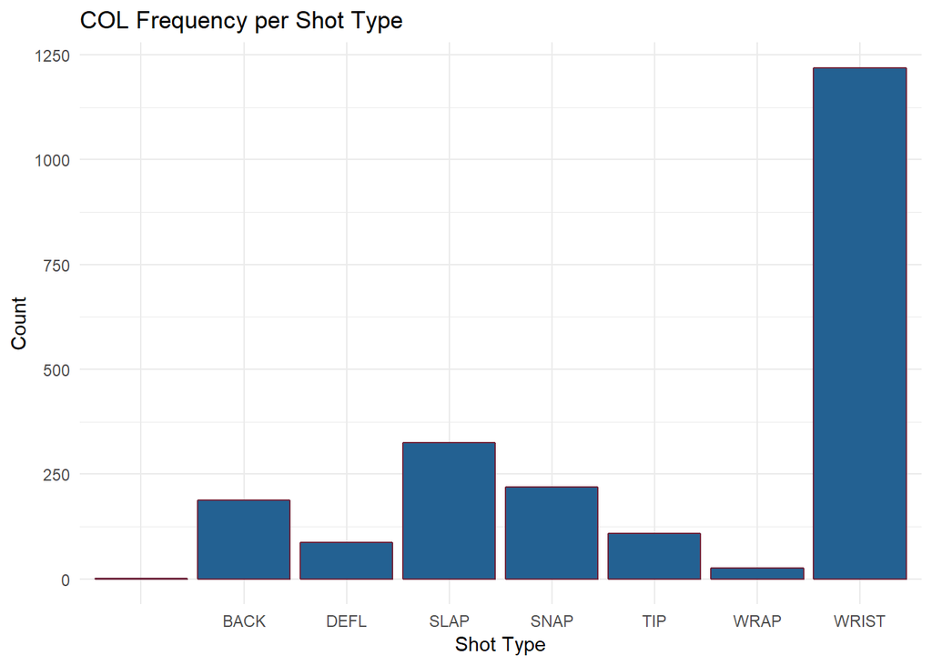

```r
col.type.freq = make.type.freq.plot(col.nnet, "#6F263D", "#236192", "COL")

col.type.freq
```

Here is how the Avalance did with shots versus goal probability from the KNN model.

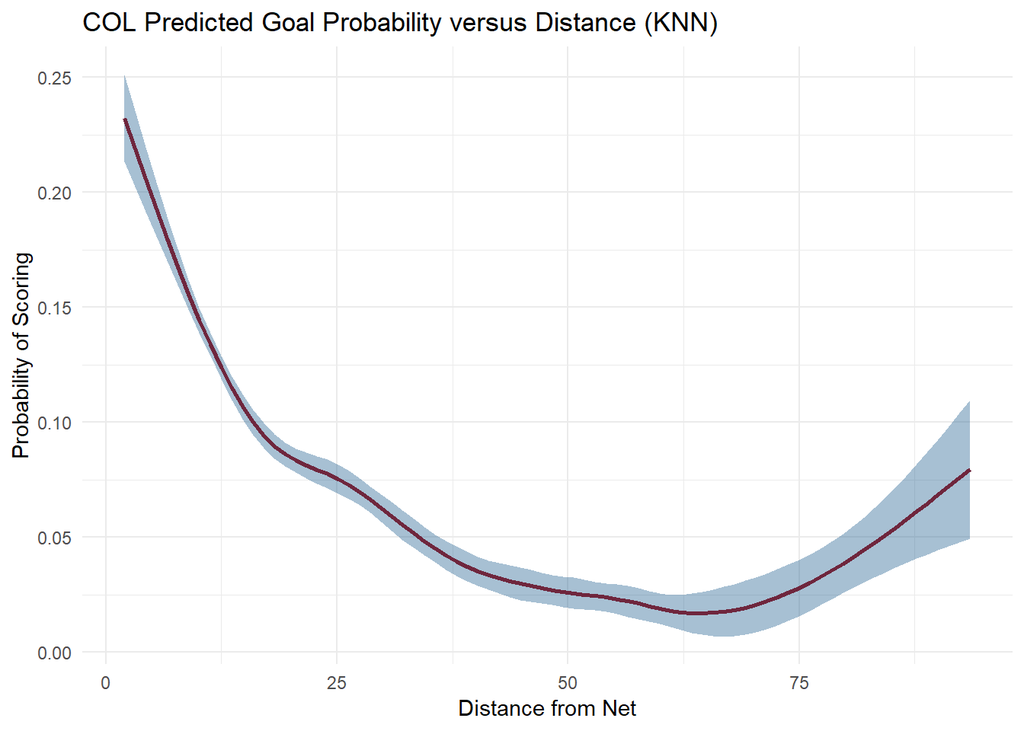

```r
col.knn.dist = make.knn.dist.plot(col.knn, "#6F263D", "#236192", "COL")

col.knn.dist
```

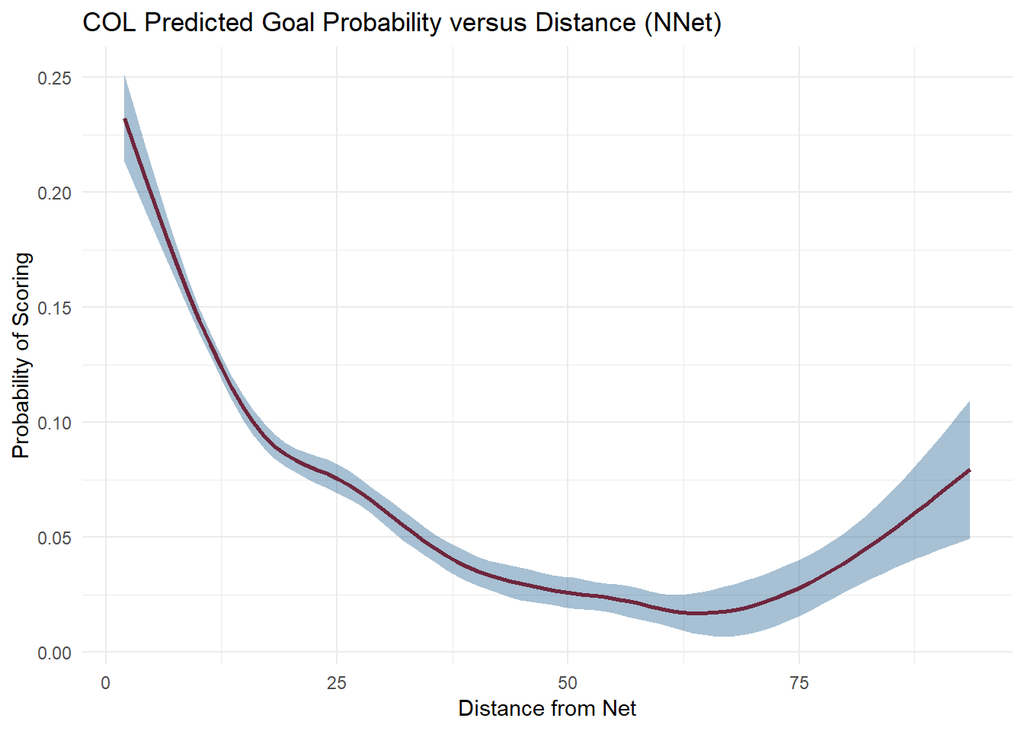

```r
col.nnet.dist = make.nnet.dist.plot(col.knn, "#6F263D", "#236192", "COL")

col.nnet.dist
```

Now let’s look at shot type versus goal probability.

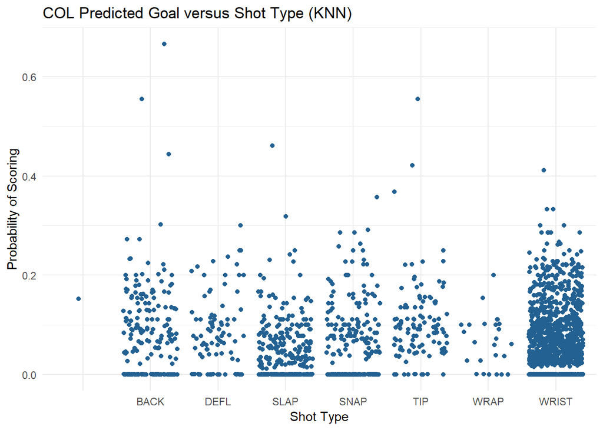

```r
col.knn.type = make.knn.type.plot(col.knn, "#6F263D", "#236192", "COL")

col.knn.type
```

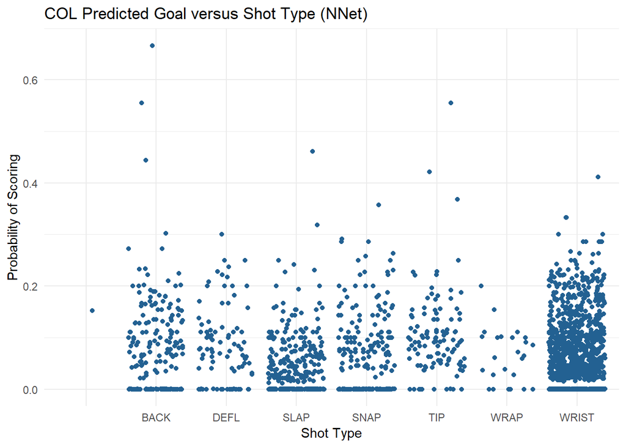

```r
col.nnet.type = make.nnet.type.plot(col.knn, "#6F263D", "#236192", "COL")

col.nnet.type
```